# Poverty and Test Performance in New York Public Schools

Yash

September 21, 2026

## Overview

**Question:** What can data tell us about the relationship between poverty and test performance in New York public schools?

The department also asked:

1. What is the difference in test performance between low, medium, and high poverty areas?
2. Has this relationship changed over time?

**Data:** School-level math and ELA scores (2009-2016) merged with county-level American Community Survey estimates (poverty rate, median household income, share with a bachelor’s degree).

## 1. Data preparation

```r
df <- read_csv("data/processed/nys_acs_school_final.csv")
glimpse(df)
```

```
## Rows: 28,550
## Columns: 19
## $ county_name             <chr> "ALBANY", "ALBANY", "ALBANY", "ALBANY", "ALBAN…
## $ year                    <dbl> 2009, 2009, 2009, 2009, 2009, 2009, 2009, 2009…
## $ county_per_poverty      <dbl> 0.1183511, 0.1183511, 0.1183511, 0.1183511, 0.…
## $ median_household_income <dbl> 55350, 55350, 55350, 55350, 55350, 55350, 5535…
## $ county_per_bach         <dbl> 0.1903682, 0.1903682, 0.1903682, 0.1903682, 0.…
## $ poverty_grp             <chr> "Low", "Low", "Low", "Low", "Low", "Low", "Low…
## $ school_cd               <chr> "010100010014", "010100010016", "010100010018"…
## $ school_name             <chr> "MONTESSORI MAGNET SCHOOL", "PINE HILLS ELEMEN…
## $ district_name           <chr> "ALBANY CITY SCHOOL DISTRICT", "ALBANY CITY SC…
## $ region                  <chr> "CAPITAL DISTRICT", "CAPITAL DISTRICT", "CAPIT…
## $ total_enroll            <dbl> 312, 327, 396, 351, 401, 501, 195, 437, 392, 4…
## $ per_free_lunch          <dbl> 0.32, 0.69, 0.67, 0.27, 0.72, 0.38, 0.59, 0.71…
## $ per_reduced_lunch       <dbl> 0.08, 0.11, 0.11, 0.08, 0.12, 0.18, 0.08, 0.16…
## $ per_lep                 <dbl> 0.02, 0.05, 0.17, 0.06, 0.03, 0.03, 0.06, 0.06…
## $ mean_ela_score          <dbl> 672.6667, 667.6667, 655.0000, 681.0000, 655.16…
## $ mean_math_score         <dbl> 678.6667, 668.6667, 663.6667, 695.3333, 652.66…
## $ country_name            <chr> "ALBANY", "ALBANY", "ALBANY", "ALBANY", "ALBAN…
## $ math_z                  <dbl> -0.3918617, -0.9937178, -1.2946459, 0.6112318,…
## $ ela_z                   <dbl> 0.240797008, -0.130865471, -1.072410418, 0.860…
```

Test scales change from time to time, so raw scores are not comparable across years. Math and ELA scores are standardized within each year (z-scores), so 0 means an average school that year. Counties are also grouped into Low/Medium/High poverty terciles.

```r
#Reshape: one row per school-year-subject
df_long <- df |>
  mutate(poverty_grp = factor(poverty_grp, levels = c("Low", "Medium", "High"))) |>
  pivot_longer(c(math_z, ela_z), names_to = "subject", values_to = "z") |>
  mutate(subject = recode(subject, math_z = "Math", ela_z = "ELA")) |>
  drop_na(z)

#Slopes: change in z-score per +10 percentage points of county poverty
slope_by <- function(data, ...) {
  data |>
    group_by(...) |>
    summarise(slope = coef(lm(z ~ county_per_poverty))[2] * 0.1, .groups = "drop") |>
    mutate(label = sprintf("%+.2f", slope))
}

slopes_overall <- slope_by(df_long, subject)
slopes_year    <- slope_by(df_long, year, subject)

dir.create("plots", showWarnings = FALSE)
```

## 2. Overall relationship

```r
slopes_overall |>
  select(Subject = subject, `Slope per +10 pts poverty` = slope) |>
  knitr::kable(digits = 3)
```

| Subject | Slope per +10 pts poverty |
| --- | --- |
| ELA | -0.534 |
| Math | -0.467 |

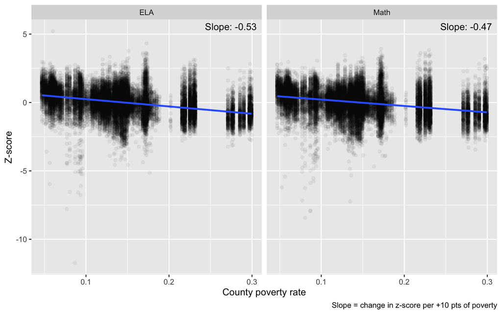

```r
p1 <- ggplot(df_long, aes(county_per_poverty, z)) +
  geom_point(alpha = 0.05) +
  geom_smooth(method = "lm", formula = y ~ x) +
  geom_text(data = slopes_overall,
            aes(x = Inf, y = Inf, label = paste("Slope:", label)),
            hjust = 1.1, vjust = 1.5, inherit.aes = FALSE) +
  facet_wrap(~subject) +
  labs(x = "County poverty rate", y = "Z-score",
       caption = "Slope = change in z-score per +10 pts of poverty")
p1
```

```r
ggsave("plots/1_poverty_vs_z.png", p1, width = 9, height = 5, dpi = 300)
```

**Takeaway:** Poverty and test performance are negatively related in both subjects: for every 10-point rise in a county’s poverty rate, ELA z-scores drop by about 0.53 and math z-scores drop by about 0.47. Both effects are similar in size, with ELA slightly more sensitive to poverty than math.

## 3. Low, medium, and high poverty areas

```r
df_long |>
  group_by(`Poverty group` = poverty_grp, Subject = subject) |>
  summarise(`Mean z-score` = mean(z), Schools = n(), .groups = "drop") |>
  knitr::kable(digits = 2)
```

| Poverty group | Subject | Mean z-score | Schools |
| --- | --- | --- | --- |
| Low | ELA | 0.12 | 21370 |
| Low | Math | 0.11 | 21366 |
| Medium | ELA | -0.28 | 3158 |
| Medium | Math | -0.23 | 3158 |
| High | ELA | -0.77 | 2245 |
| High | Math | -0.70 | 2245 |

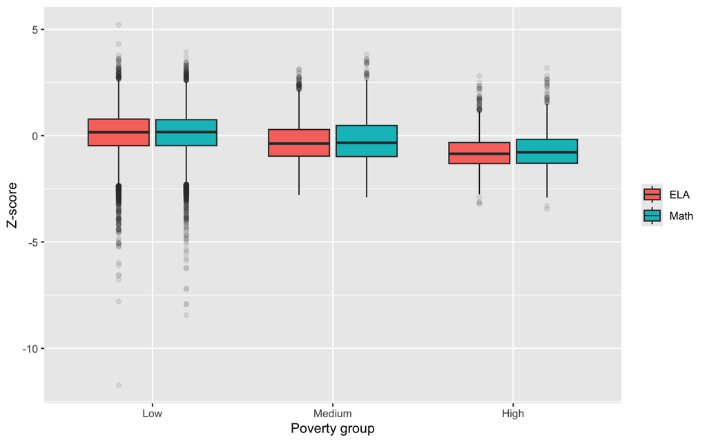

```r
p2 <- ggplot(df_long, aes(poverty_grp, z, fill = subject)) +
  geom_boxplot(outlier.alpha = 0.1) +
  labs(x = "Poverty group", y = "Z-score", fill = NULL)
p2
```

```r
ggsave("plots/2_poverty_group_vs_z.png", p2, width = 7, height = 5, dpi = 300)
```

**Takeaway:** Schools in high-poverty counties score noticeably lower than those in low-poverty counties in both subjects, with the medium-poverty group falling in between. The gap between low and high poverty groups is roughly similar for ELA and math, and it’s a step-wise decline rather than a jump concentrated in one group.

## 4. Has the relationship changed over time?

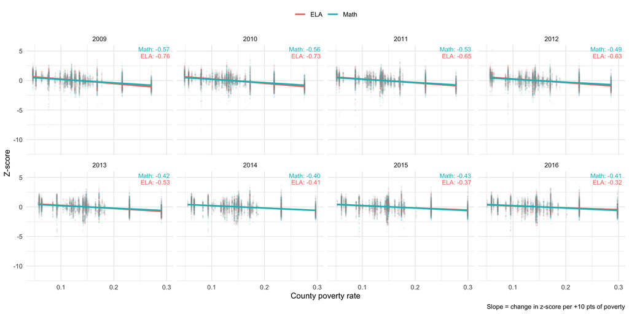

```r
p3 <- ggplot(df_long, aes(county_per_poverty, z, color = subject)) +
  geom_point(alpha = 0.05, size = 0.4) +
  geom_smooth(method = "lm", formula = y ~ x, se = FALSE) +
  geom_text(data = slopes_year,
            aes(x = Inf, y = Inf, label = paste0(subject, ": ", label),
                vjust = if_else(subject == "Math", 1.5, 3)),
            hjust = 1.1, size = 3, show.legend = FALSE) +
  facet_wrap(~year, nrow = 2) +
  labs(x = "County poverty rate", y = "Z-score", color = NULL,
       caption = "Slope = change in z-score per +10 pts of poverty") +
  theme_minimal() +
  theme(legend.position = "top")
p3
```

```r
ggsave("plots/3_poverty_vs_z_by_year.png", p3, width = 14, height = 7, dpi = 300)
```

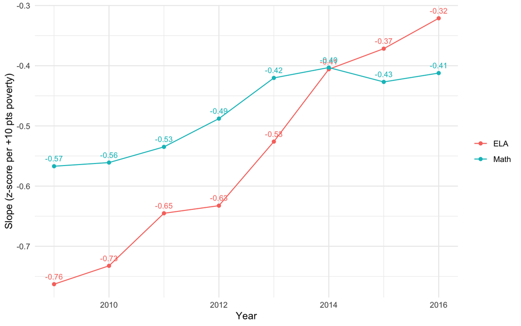

```r
p4 <- ggplot(slopes_year, aes(year, slope, color = subject)) +
  geom_line() +
  geom_point() +
  geom_text(aes(label = label), vjust = -0.9, size = 3, show.legend = FALSE) +
  labs(x = "Year", y = "Slope (z-score per +10 pts poverty)", color = NULL) +
  theme_minimal()
p4
```

```r
ggsave("plots/4_slope_over_time.png", p4, width = 7, height = 5, dpi = 300)
```

## 5. Caveats

- Poverty is measured at the **county** level, so every school in a county shares the same poverty value in a given year. The relationship describes county context, not each school’s own student population.
- Z-scores are standardized within each year, so they show relative standing, not absolute gains or losses in performance.
- This is an association, not a causal claim: it does not show that poverty causes lower scores.